## In-class worksheet 10

**Feb 19, 2015**

# 1. k-means clustering of the iris data set

We can do k-means clustering in R using the function `kmeans()`. The primary argument to this function is `centers`, which tells the function how many cluster centers we want to use:

```r
iris %>% select(-Species) %>% # remove Species column
  kmeans(centers=3) ->        # do k-means clustering with 3 centers
  km                          # store result as `km`

# now display the results from the analysis
km
```

```
## K-means clustering with 3 clusters of sizes 33, 96, 21
##
## Cluster means:
##   Sepal.Length Sepal.Width Petal.Length Petal.Width
## 1        5.176       3.624        1.473      0.2727
## 2        6.315       2.896        4.974      1.7031
## 3        4.738       2.905        1.790      0.3524
##
## Clustering vector:
##   [1] 1 3 3 3 1 1 1 1 3 3 1 1 3 3 1 1 1 1 1 1 1 1 1 1 3 3 1 1 1 3 3 1 1 1 3
##  [36] 1 1 1 3 1 1 3 3 1 1 3 1 3 1 1 2 2 2 2 2 2 2 3 2 2 3 2 2 2 2 2 2 2 2 2
##  [71] 2 2 2 2 2 2 2 2 2 2 2 2 2 2 2 2 2 2 2 2 2 2 2 3 2 2 2 2 3 2 2 2 2 2 2
## [106] 2 2 2 2 2 2 2 2 2 2 2 2 2 2 2 2 2 2 2 2 2 2 2 2 2 2 2 2 2 2 2 2 2 2 2
## [141] 2 2 2 2 2 2 2 2 2 2
##
## Within cluster sum of squares by cluster:
## [1]   6.432 118.652  17.670
##  (between_SS / total_SS =  79.0 %)
##
## Available components:
##
## [1] "cluster"      "centers"      "totss"        "withinss"
## [5] "tot.withinss" "betweenss"    "size"         "iter"
## [9] "ifault"
```

The cluster means give us the locations of the centroids of the three clusters. We can access them directly via `km$centers`:

```r
km$centers
```

```
##   Sepal.Length Sepal.Width Petal.Length Petal.Width
## 1        5.176       3.624        1.473      0.2727
## 2        6.315       2.896        4.974      1.7031
## 3        4.738       2.905        1.790      0.3524
```

The clustering vector tells us for each data point to which cluster it belongs. We can access this vector directly via `km$cluster`:

```r
km$cluster
```

```
##   [1] 1 3 3 3 1 1 1 1 3 3 1 1 3 3 1 1 1 1 1 1 1 1 1 1 3 3 1 1 1 3 3 1 1 1 3
##  [36] 1 1 1 3 1 1 3 3 1 1 3 1 3 1 1 2 2 2 2 2 2 2 3 2 2 3 2 2 2 2 2 2 2 2 2
##  [71] 2 2 2 2 2 2 2 2 2 2 2 2 2 2 2 2 2 2 2 2 2 2 2 3 2 2 2 2 3 2 2 2 2 2 2
## [106] 2 2 2 2 2 2 2 2 2 2 2 2 2 2 2 2 2 2 2 2 2 2 2 2 2 2 2 2 2 2 2 2 2 2 2
## [141] 2 2 2 2 2 2 2 2 2 2
```

We can add this vector to the iris data frame and then plot, coloring by cluster and using different symbol shapes according to species, for comparison:

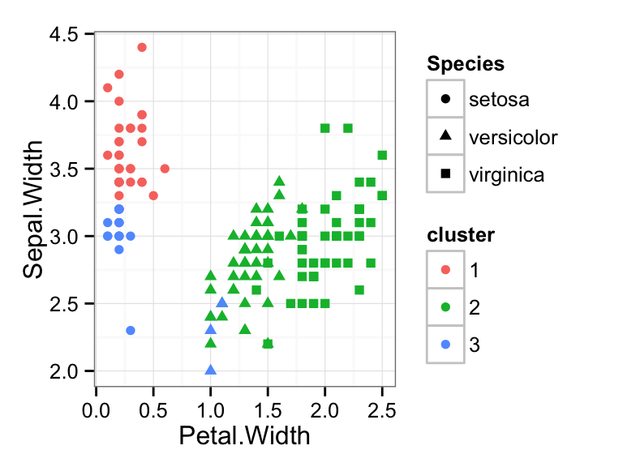

```r
# add species information back into PCA data
# we use `factor(km$cluster)` to tell R that the cluster numbers represent distinct categories,
# not continuous values
iris_clustered <- data.frame(iris, cluster=factor(km$cluster))
ggplot(iris_clustered, aes(x=Petal.Width, y=Sepal.Width, color=cluster, shape=Species)) + geom_point()
```

Let’s do everything once more:

```r
iris %>% select(-Species) %>% kmeans(centers=3) -> km
iris_clustered <- data.frame(iris, cluster=factor(km$cluster))
ggplot(iris_clustered, aes(x=Petal.Width, y=Sepal.Width, color=cluster, shape=Species)) + geom_point()
```

[output not shown]

*What do you notice? Repeat the clustering and plotting three more times. Do you always get the same result?*

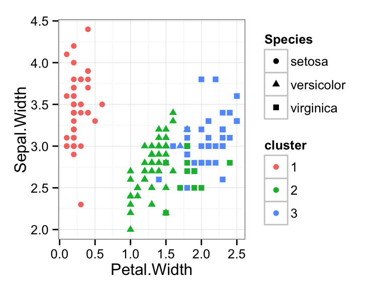

```r
iris %>% select(-Species) %>% kmeans(centers=3) -> km
iris_clustered <- data.frame(iris, cluster=factor(km$cluster))
ggplot(iris_clustered, aes(x=Petal.Width, y=Sepal.Width, color=cluster, shape=Species)) + geom_point()
```

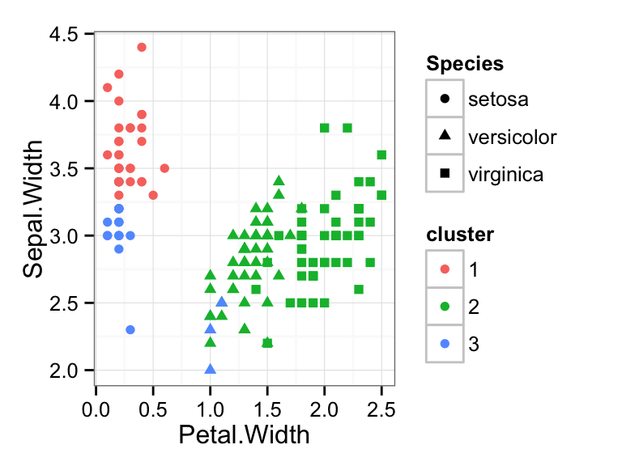

```r
iris %>% select(-Species) %>% kmeans(centers=3) -> km
iris_clustered <- data.frame(iris, cluster=factor(km$cluster))
ggplot(iris_clustered, aes(x=Petal.Width, y=Sepal.Width, color=cluster, shape=Species)) + geom_point()
```

```r
iris %>% select(-Species) %>% kmeans(centers=3) -> km
iris_clustered <- data.frame(iris, cluster=factor(km$cluster))
ggplot(iris_clustered, aes(x=Petal.Width, y=Sepal.Width, color=cluster, shape=Species)) + geom_point()
```

[output not shown]

Everytime we cluster, we get different results. Sometimes the results are totally useless.

*Look up the meaning of the parameter `nstart` in the documentation to `kmeans()`. Can you use it to make the results more reliable?*

We can use `nstart` to set the number of different initial configurations the clustering algorithm tries. By setting `nstart=10`, for example, results become more reliable:

```r
iris %>% select(-Species) %>% kmeans(centers=3, nstart=10) -> km
iris_clustered <- data.frame(iris, cluster=factor(km$cluster))
ggplot(iris_clustered, aes(x=Petal.Width, y=Sepal.Width, color=cluster, shape=Species)) + geom_point()
```

[output not shown]

```r
iris %>% select(-Species) %>% kmeans(centers=3, nstart=10) -> km
iris_clustered <- data.frame(iris, cluster=factor(km$cluster))
ggplot(iris_clustered, aes(x=Petal.Width, y=Sepal.Width, color=cluster, shape=Species)) + geom_point()
```

[output not shown]

```r
iris %>% select(-Species) %>% kmeans(centers=3, nstart=10) -> km
iris_clustered <- data.frame(iris, cluster=factor(km$cluster))
ggplot(iris_clustered, aes(x=Petal.Width, y=Sepal.Width, color=cluster, shape=Species)) + geom_point()
```

[output not shown]

*Now try different numbers of centers and see what you get.*

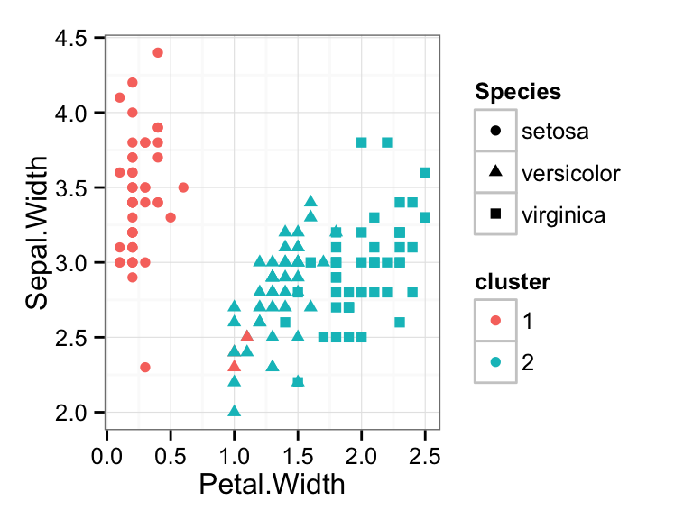

```r
iris %>% select(-Species) %>% kmeans(centers=2, nstart=10) -> km
iris_clustered <- data.frame(iris, cluster=factor(km$cluster))
ggplot(iris_clustered, aes(x=Petal.Width, y=Sepal.Width, color=cluster, shape=Species)) + geom_point()
```

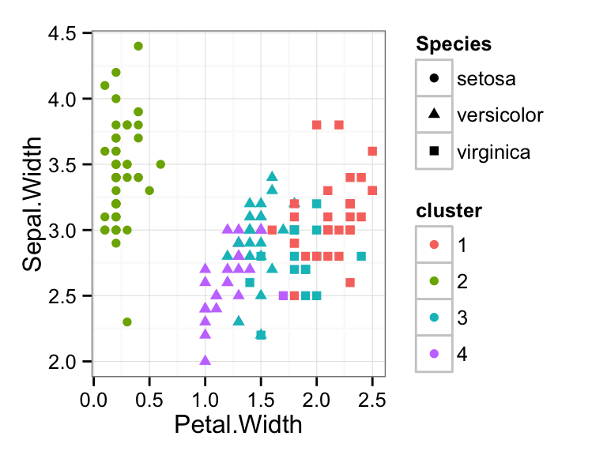

```r
iris %>% select(-Species) %>% kmeans(centers=4, nstart=10) -> km
iris_clustered <- data.frame(iris, cluster=factor(km$cluster))
ggplot(iris_clustered, aes(x=Petal.Width, y=Sepal.Width, color=cluster, shape=Species)) + geom_point()
```

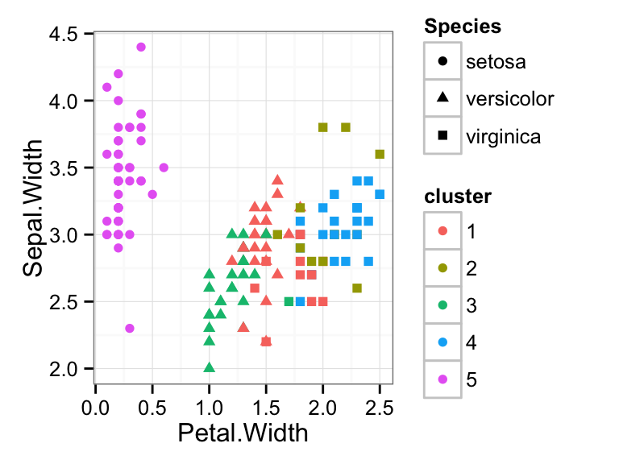

```r
iris %>% select(-Species) %>% kmeans(centers=5, nstart=10) -> km
iris_clustered <- data.frame(iris, cluster=factor(km$cluster))
ggplot(iris_clustered, aes(x=Petal.Width, y=Sepal.Width, color=cluster, shape=Species)) + geom_point()
```

# 2. Clustering the biopsy data set

*Take the `biopsy` data set, cluster it into 2, 3, or 4 clusters, and display the clusters in principal-component space. (In other words, plot PC2 vs PC1 and color by cluster. You can set the plotting symbol by outcome, to see how clustering compares with known outcomes.)*

```r
# load in the biopsy data set
biopsy <- read.csv("http://wilkelab.org/classes/SDS348/data_sets/biopsy.csv")
head(biopsy)
```

```
##   clump_thickness uniform_cell_size uniform_cell_shape marg_adhesion
## 1               5                 1                  1             1
## 2               5                 4                  4             5
## 3               3                 1                  1             1
## 4               6                 8                  8             1
## 5               4                 1                  1             3
## 6               8                10                 10             8
##   epithelial_cell_size bare_nuclei bland_chromatin normal_nucleoli mitoses
## 1                    2           1               3               1       1
## 2                    7          10               3               2       1
## 3                    2           2               3               1       1
## 4                    3           4               3               7       1
## 5                    2           1               3               1       1
## 6                    7          10               9               7       1
##     outcome
## 1    benign
## 2    benign
## 3    benign
## 4    benign
## 5    benign
## 6 malignant
```

```r
# do PCA on biopsy data set
biopsy %>% select(-outcome) %>% scale() %>% prcomp() -> pca
```

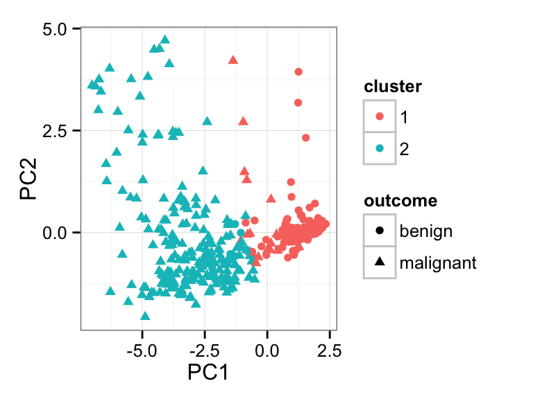

```r
# 2 clusters
biopsy %>% select(-outcome) %>% kmeans(centers=2, nstart=10) -> km
cluster_data <- data.frame(pca$x, cluster=factor(km$cluster), outcome=biopsy$outcome)
ggplot(cluster_data, aes(x=PC1, y=PC2, color=cluster, shape=outcome)) + geom_point()
```

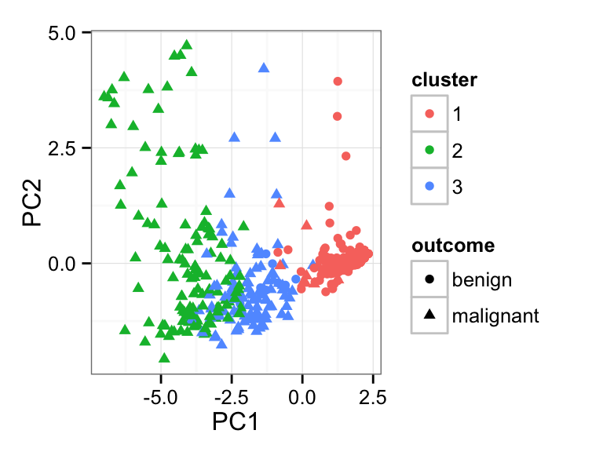

```r
# 3 clusters
biopsy %>% select(-outcome) %>% kmeans(centers=3, nstart=10) -> km
cluster_data <- data.frame(pca$x, cluster=factor(km$cluster), outcome=biopsy$outcome)
ggplot(cluster_data, aes(x=PC1, y=PC2, color=cluster, shape=outcome)) + geom_point()
```

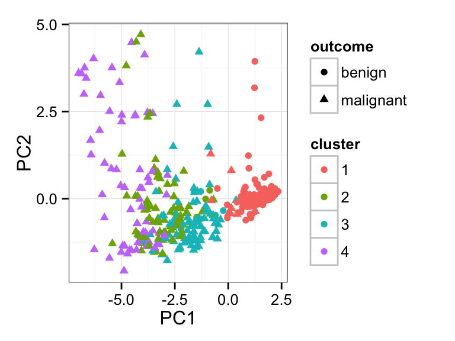

```r
# 4 clusters
biopsy %>% select(-outcome) %>% kmeans(centers=4, nstart=10) -> km
cluster_data <- data.frame(pca$x, cluster=factor(km$cluster), outcome=biopsy$outcome)
ggplot(cluster_data, aes(x=PC1, y=PC2, color=cluster, shape=outcome)) + geom_point()
```

Even with four clusters, we end up clustering some malignant cases among the benign cases. It looks like k-means clustering is not a reliable method to separate the malignant and benign cases.

# 3. If this was easy

*Let’s go back to the original clustering of the iris data set, with 3 clusters:*

```r
iris %>% select(-Species) %>% kmeans(centers=3, nstart=10) -> km
iris_clustered <- data.frame(iris, cluster=factor(km$cluster))
ggplot(iris_clustered, aes(x=Petal.Width, y=Sepal.Width, color=cluster, shape=Species)) + geom_point()
```

[output not shown]

*Take this plot and add to it the location of the centroids for each cluster, plotted as large, colored circles with a black outline.*

```r
# first we need to capture the centroids in a data frame
centroids <- data.frame(km$centers)
centroids
```

```
##   Sepal.Length Sepal.Width Petal.Length Petal.Width
## 1        5.006       3.428        1.462       0.246
## 2        6.850       3.074        5.742       2.071
## 3        5.902       2.748        4.394       1.434
```

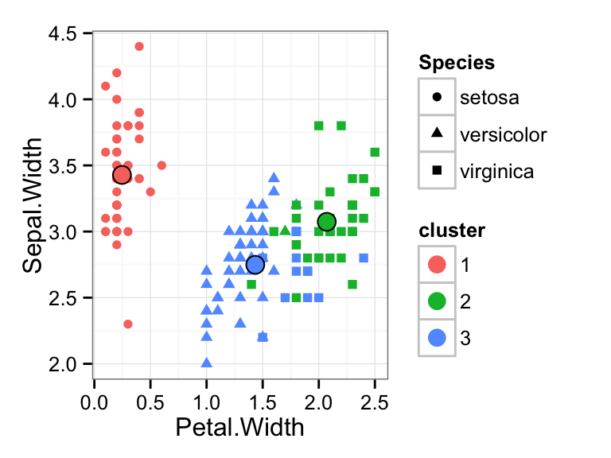

```r
# then we need to add a column that indicates the cluster number. Again we use
# factor() to express that the cluster numbers are discrete categories.
centroids <- data.frame(centroids, cluster=factor(1:3))
# now we can plot
ggplot(iris_clustered, aes(x=Petal.Width, y=Sepal.Width, color=cluster)) +
  geom_point(aes(shape=Species)) + # individual points from the `iris_clustered` data frame
  geom_point(data=centroids, size=4) + # centroids
  geom_point(data=centroids, shape=1, color="black", size=4) # black outline for centroids
```